# Comparing BiLSTM and ABC Calibration for SIR Models

## Method 2: ABC Calibration

### Load Pre-Calibrated ABC Results

```r
cat("\n=== ABC Calibration (Pre-computed) ===\n")
```

```
=== ABC Calibration (Pre-computed) ===
```

```r
# Load the calibration data
data("abc_calibration_params")

# Extract calibrated parameters
abc_crate <- abc_calibration_params$contact_rate
abc_recov <- abc_calibration_params$recovery_rate
abc_ptran <- abc_calibration_params$transmission_prob
abc_R0 <- abc_calibration_params$R0

# Extract confidence intervals
abc_lower <- c(
  abc_calibration_params$contact_rate_ci["lower"],
  abc_calibration_params$recovery_rate_ci["lower"],
  abc_calibration_params$transmission_prob_ci["lower"]
)
abc_upper <- c(
  abc_calibration_params$contact_rate_ci["upper"],
  abc_calibration_params$recovery_rate_ci["upper"],
  abc_calibration_params$transmission_prob_ci["upper"]
)
abc_median <- c(abc_crate, abc_recov, abc_ptran)

# Get timing information
abc_time_minutes <- abc_calibration_params$calibration_time_seconds / 60

# Get configuration
N_abc <- 20000 # From your original configuration

n_samples_abc <- abc_calibration_params$n_samples
burnin_abc <- abc_calibration_params$burnin

cat("ABC Configuration:\n")
```

```
ABC Configuration:
```

```r
cat("Population size:", N_abc, "\n")
```

```
Population size: 20000
```

```r
cat("MCMC samples:", n_samples_abc, "(", burnin_abc, "burn-in)\n")
```

```
MCMC samples: 3000 ( 1500 burn-in)
```

```r
cat("Epsilon:", round(abc_calibration_params$epsilon, 2), "\n")
```

```
Epsilon: 10
```

```r
cat("Original computation time:", round(abc_time_minutes, 2), "minutes\n\n")
```

```
Original computation time: 3.72 minutes
```

```r
cat("Calibrated Parameters (Median with 95% CI):\n")
```

```
Calibrated Parameters (Median with 95% CI):
```

```r
cat("Contact Rate:      ", sprintf("%.4f", abc_crate),
    " [", sprintf("%.4f", abc_lower[1]), ", ", sprintf("%.4f", abc_upper[1]), "]\n", sep = "")
```

```
Contact Rate:      1.1789 [0.8912, 1.5443]
```

```r
cat("Recovery Rate:     ", sprintf("%.4f", abc_recov),
    " [", sprintf("%.4f", abc_lower[2]), ", ", sprintf("%.4f", abc_upper[2]), "]\n", sep = "")
```

```
Recovery Rate:     0.0937 [0.0749, 0.1496]
```

```r
cat("Transmission Prob: ", sprintf("%.4f", abc_ptran),
    " [", sprintf("%.4f", abc_lower[3]), ", ", sprintf("%.4f", abc_upper[3]), "]\n", sep = "")
```

```
Transmission Prob: 0.1184 [0.1006, 0.1554]
```

```r
cat("R0:                ", sprintf("%.4f", abc_R0), "\n", sep = "")
```

```
R0:                1.4898
```

### ABC Posterior Distributions

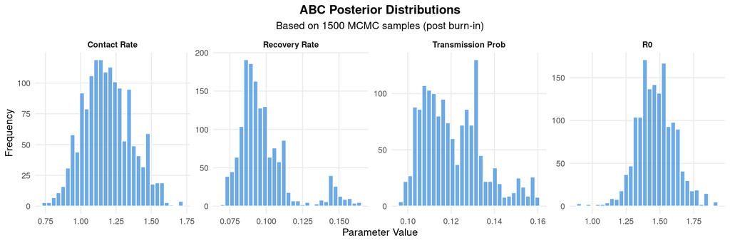

```r
# Extract posterior samples
posterior <- abc_calibration_params$posterior_samples

# Calculate R0 from posterior samples
R0_samples <- (posterior[, 1] * posterior[, 3]) / posterior[, 2]

# Create data frame for plotting
posterior_df <- data.frame(
  contact_rate = posterior[, 1],
  recovery_rate = posterior[, 2],
  transmission_prob = posterior[, 3],
  R0 = R0_samples
)

# Reshape for faceted plot
posterior_long <- posterior_df %>%
  pivot_longer(cols = everything(), names_to = "parameter", values_to = "value") %>%
  mutate(parameter = factor(parameter,
    levels = c("contact_rate", "recovery_rate", "transmission_prob", "R0"),
    labels = c("Contact Rate", "Recovery Rate", "Transmission Prob", "R0")
  ))

# Plot posterior distributions
ggplot(posterior_long, aes(x = value)) +
  geom_histogram(bins = 30, fill = "#2E86DE", alpha = 0.7, color = "white") +
  facet_wrap(~parameter, scales = "free", ncol = 4) +
  labs(
    title = "ABC Posterior Distributions",
    subtitle = paste0("Based on ", nrow(posterior), " MCMC samples (post burn-in)"),
    x = "Parameter Value",
    y = "Frequency"
  ) +
  theme_minimal(base_size = 12) +
  theme(
    plot.title = element_text(face = "bold", hjust = 0.5),
    plot.subtitle = element_text(hjust = 0.5),
    strip.text = element_text(face = "bold"),
    panel.grid.minor = element_blank()
  )
```

### Stochastic Simulations (ABC)

```r
cat("\n=== Running 2,000 Stochastic Simulations (ABC) ===\n")
```

```
=== Running 2,000 Stochastic Simulations (ABC) ===
```

```r
initial_infected <- incidence_vec[1]
initial_prevalence <- initial_infected / N

abc_model <- ModelSIRCONN(
  name              = "ABC SIR",
  n                 = N,
  prevalence        = initial_prevalence,
  contact_rate      = abc_crate,
  transmission_rate = abc_ptran,
  recovery_rate     = abc_recov
)

saver_abc <- make_saver("transition")

tic("ABC simulations")
run_multiple(
  abc_model,
  ndays    = model_ndays,
  nsims    = 2000,
  saver    = saver_abc,
  nthreads = 8
)
```

```
Starting multiple runs (2000) using 8 thread(s)
_________________________________________________________________________
_________________________________________________________________________
||||||||||||||||||||||||||||||||||||||||||||||||||||||||||||||||||||||||| done.
```

```r
abc_sim_time <- toc()
```

```
ABC simulations: 18.365 sec elapsed
```

```r
abc_sim_results <- run_multiple_get_results(
  abc_model,
  nthreads = 8,
  freader = data.table::fread
)
```

### Extract ABC Confidence Intervals

```r
abc_transitions <- abc_sim_results$transition %>%
  filter(from == "Susceptible", to == "Infected") %>%
  arrange(sim_num, date)

abc_quantiles <- abc_transitions %>%
  group_by(date) %>%
  summarize(
    lower_ci = quantile(counts, 0.025),
    upper_ci = quantile(counts, 0.975),
    median   = quantile(counts, 0.5),
    mean     = mean(counts),
    .groups  = "drop"
  )
```

## Comparison

### Timing Summary

```r
bilstm_total_mins <- (bilstm_time$toc - bilstm_time$tic) / 60
speedup <- abc_time_minutes / bilstm_total_mins

cat("=== Computational Time Comparison ===\n\n")
```

```
=== Computational Time Comparison ===
```

```r
cat("BiLSTM calibration:", round(bilstm_total_mins, 2), "minutes\n")
```

```
BiLSTM calibration: 0.07 minutes
```

```r
cat("ABC calibration:", round(abc_time_minutes, 2), "minutes (pre-computed)\n")
```

```
ABC calibration: 3.72 minutes (pre-computed)
```

```r
cat("\nSpeedup: BiLSTM is", round(speedup, 1), "x FASTER than ABC\n")
```

```
Speedup: BiLSTM is 55.5 x FASTER than ABC
```

### Parameter Comparison

```r
comparison_df <- data.frame(
  Parameter = c("Contact Rate", "Recovery Rate", "Trans. Prob", "R0"),
  BiLSTM = c(
    lstm_predictions[["crate"]],
    recov,
    lstm_predictions[["ptran"]],
    lstm_predictions[["R0"]]
  ),
  ABC = c(abc_crate, abc_recov, abc_ptran, abc_R0),
  Difference = c(
    lstm_predictions[["crate"]] - abc_crate,
    recov - abc_recov,
    lstm_predictions[["ptran"]] - abc_ptran,
    lstm_predictions[["R0"]] - abc_R0
  ),
  Pct_Diff = c(
    (lstm_predictions[["crate"]] - abc_crate) / abc_crate * 100,
    (recov - abc_recov) / abc_recov * 100,
    (lstm_predictions[["ptran"]] - abc_ptran) / abc_ptran * 100,
    (lstm_predictions[["R0"]] - abc_R0) / abc_R0 * 100
  )
)

knitr::kable(comparison_df, digits = 4,
             caption = "Parameter Estimates: BiLSTM vs ABC")
```

Parameter Estimates: BiLSTM vs ABC

| Parameter | BiLSTM | ABC | Difference | Pct_Diff |
| --- | --- | --- | --- | --- |
| Contact Rate | 2.8389 | 1.1789 | 1.6600 | 140.8026 |
| Recovery Rate | 0.1429 | 0.0937 | 0.0491 | 52.4241 |
| Trans. Prob | 0.0606 | 0.1184 | -0.0578 | -48.8402 |
| R0 | 1.2041 | 1.4898 | -0.2857 | -19.1768 |

### Parameter Uncertainty Analysis

```r
# Calculate R0 statistics from posterior
R0_samples_calc <- (posterior[, 1] * posterior[, 3]) / posterior[, 2]
abc_R0_lower <- quantile(R0_samples_calc, 0.025)
abc_R0_upper <- quantile(R0_samples_calc, 0.975)
abc_R0_sd <- sd(R0_samples_calc)

# Calculate SD for other parameters
abc_sd <- apply(posterior, 2, sd)

# Create summary table with uncertainties
uncertainty_df <- data.frame(
  Parameter = c("Contact Rate", "Recovery Rate", "Transmission Prob", "R0"),
  ABC_Median = c(
    abc_median[1],
    abc_median[2],
    abc_median[3],
    abc_R0
  ),
  ABC_Lower = c(
    abc_lower[1],
    abc_lower[2],
    abc_lower[3],
    abc_R0_lower
  ),
  ABC_Upper = c(
    abc_upper[1],
    abc_upper[2],
    abc_upper[3],
    abc_R0_upper
  ),
  ABC_SD = c(
    abc_sd[1],
    abc_sd[2],
    abc_sd[3],
    abc_R0_sd
  ),
  BiLSTM_Point = c(
    lstm_predictions[["crate"]],
    recov,
    lstm_predictions[["ptran"]],
    lstm_predictions[["R0"]]
  )
)

knitr::kable(uncertainty_df, digits = 4,
             caption = "Parameter Uncertainty: ABC provides full posterior distributions")
```

Parameter Uncertainty: ABC provides full posterior distributions

| Parameter | ABC_Median | ABC_Lower | ABC_Upper | ABC_SD | BiLSTM_Point |
| --- | --- | --- | --- | --- | --- |
| Contact Rate | 1.1789 | 0.8912 | 1.5443 | 0.1705 | 2.8389 |
| Recovery Rate | 0.0937 | 0.0749 | 0.1496 | 0.0182 | 0.1429 |
| Transmission Prob | 0.1184 | 0.1006 | 0.1554 | 0.0141 | 0.0606 |
| R0 | 1.4898 | 1.2160 | 1.7656 | 0.1387 | 1.2041 |

### Combined Visualization

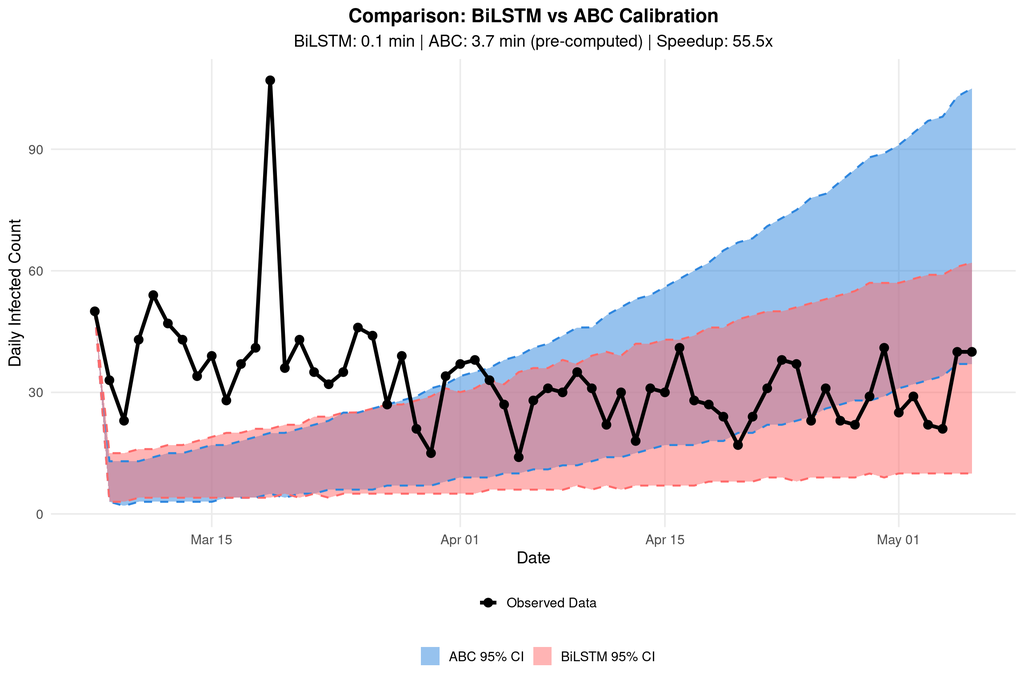

```r
# Prepare data
plot_df <- data.frame(
  Date = covid_data$Date,
  Observed = incidence,
  BiLSTM_median = bilstm_quantiles$median,
  BiLSTM_lower = bilstm_quantiles$lower_ci,
  BiLSTM_upper = bilstm_quantiles$upper_ci,
  ABC_median = abc_quantiles$median,
  ABC_lower = abc_quantiles$lower_ci,
  ABC_upper = abc_quantiles$upper_ci
)

# Main comparison plot with distinct colors and boundary lines
p_comparison <- ggplot(plot_df, aes(x = Date)) +
  # ABC CI ribbon (bright blue)
  geom_ribbon(
    aes(ymin = ABC_lower, ymax = ABC_upper, fill = "ABC 95% CI"),
    alpha = 0.5
  ) +
  # BiLSTM CI ribbon (bright coral/red)
  geom_ribbon(
    aes(ymin = BiLSTM_lower, ymax = BiLSTM_upper, fill = "BiLSTM 95% CI"),
    alpha = 0.5
  ) +
  # ABC boundary lines (dashed blue)
  geom_line(
    aes(y = ABC_lower),
    color = "#2E86DE",
    linetype = "dashed",
    linewidth = 0.8
  ) +
  geom_line(
    aes(y = ABC_upper),
    color = "#2E86DE",
    linetype = "dashed",
    linewidth = 0.8
  ) +
  # BiLSTM boundary lines (dashed red)
  geom_line(
    aes(y = BiLSTM_lower),
    color = "#FF6B6B",
    linetype = "dashed",
    linewidth = 0.8
  ) +
  geom_line(
    aes(y = BiLSTM_upper),
    color = "#FF6B6B",
    linetype = "dashed",
    linewidth = 0.8
  ) +
  # Observed data (thick black line and points)
  geom_line(
    aes(y = Observed, color = "Observed"),
    linewidth = 1.5
  ) +
  geom_point(
    aes(y = Observed, color = "Observed"),
    size = 3
  ) +
  scale_color_manual(
    name = "",
    values = c("Observed" = "black"),
    labels = c("Observed Data")
  ) +
  scale_fill_manual(
    name = "",
    values = c(
      "ABC 95% CI" = "#2E86DE",      # Bright blue
      "BiLSTM 95% CI" = "#FF6B6B"    # Bright coral/red
    ),
    labels = c("ABC 95% CI", "BiLSTM 95% CI")
  ) +
  labs(
    title = "Comparison: BiLSTM vs ABC Calibration",
    subtitle = paste0(
      "BiLSTM: ", round(bilstm_total_mins, 1), " min | ",
      "ABC: ", round(abc_time_minutes, 1), " min (pre-computed) | ",
      "Speedup: ", round(speedup, 1), "x"
    ),
    x = "Date",
    y = "Daily Infected Count"
  ) +
  theme_minimal(base_size = 14) +
  theme(
    legend.position = "bottom",
    plot.title = element_text(size = 16, face = "bold", hjust = 0.5),
    plot.subtitle = element_text(hjust = 0.5),
    legend.box = "vertical",
    panel.grid.minor = element_blank()
  ) +
  guides(
    color = guide_legend(order = 1),
    fill = guide_legend(order = 2)
  )

print(p_comparison)
```

### Model Performance

```r
# BiLSTM metrics
bilstm_coverage <- plot_df %>%
  mutate(in_ci = Observed >= BiLSTM_lower & Observed <= BiLSTM_upper) %>%
  summarize(coverage = mean(in_ci) * 100) %>%
  pull(coverage)

bilstm_rmse <- sqrt(mean((plot_df$BiLSTM_median - plot_df$Observed)^2))
bilstm_mae <- mean(abs(plot_df$BiLSTM_median - plot_df$Observed))

# ABC metrics
abc_coverage <- plot_df %>%
  mutate(in_ci = Observed >= ABC_lower & Observed <= ABC_upper) %>%
  summarize(coverage = mean(in_ci) * 100) %>%
  pull(coverage)

abc_rmse <- sqrt(mean((plot_df$ABC_median - plot_df$Observed)^2))
abc_mae <- mean(abs(plot_df$ABC_median - plot_df$Observed))

# Create comparison table
metrics_df <- data.frame(
  Metric = c("95% CI Coverage (%)", "RMSE", "MAE", "Calibration Time (min)"),
  BiLSTM = c(
    round(bilstm_coverage, 1),
    round(bilstm_rmse, 2),
    round(bilstm_mae, 2),
    round(bilstm_total_mins, 2)
  ),
  ABC = c(
    round(abc_coverage, 1),
    round(abc_rmse, 2),
    round(abc_mae, 2),
    round(abc_time_minutes, 2)
  )
)

knitr::kable(metrics_df,
             caption = "Model Performance Comparison")
```

Model Performance Comparison

| Metric | BiLSTM | ABC |
| --- | --- | --- |
| 95% CI Coverage (%) | 62.30 | 49.20 |
| RMSE | 21.68 | 25.48 |
| MAE | 15.75 | 20.36 |
| Calibration Time (min) | 0.07 | 3.72 |

## Summary

This analysis demonstrates that:

### Key Advantages

**BiLSTM:** - Extremely fast calibration (<1 minute) - Point estimates for rapid decision-making - Suitable for operational deployment - Real-time epidemic monitoring

**ABC:** - Complete posterior distributions - Full uncertainty quantification - Credible intervals for all parameters - Ideal for research and policy analysis - Better for understanding parameter uncertainty

### Recommendation

The choice between methods depends on the use case: - **BiLSTM** for speed and operational deployment - **ABC** for comprehensive uncertainty quantification and parameter inference - **Hybrid approach**: Use BiLSTM for initial screening, ABC for detailed analysis

### Package Data Note

This vignette uses pre-computed ABC calibration results stored in `abc_calibration_results`. The ABC calibration was performed using LFMCMC with 3000 samples (1500 burn-in) and took approximately 4 minutes to complete.

To re-run the ABC calibration yourself, see the script in `data-raw/abc_calibration_results.R`.